# Exercise 14: Spatial statistics for spatial omics data

## Load some packages

```r
library(SpatialExperiment)
library(SingleCellExperiment)
library(ggspavis)
library(scater)
library(spatstat)
library(dplyr)
library(ggplot2)
```

## Question 1. Using the `HumanCerebellum` dataset available from `ExperimentHub`, calculate measures of spatial dependence/variability of gene expression.

```r
(se <- TENxVisiumData::HumanCerebellum())
```

```
class: SpatialExperiment
dim: 36601 4992
metadata(0):
assays(1): counts
rownames(36601): ENSG00000243485 ENSG00000237613 ... ENSG00000278817
  ENSG00000277196
rowData names(1): symbol
colnames(4992): AAACAACGAATAGTTC-1 AAACAAGTATCTCCCA-1 ...
  TTGTTTGTATTACACG-1 TTGTTTGTGTAAATTC-1
colData names(1): sample_id
reducedDimNames(0):
mainExpName: NULL
altExpNames(1): TargetedNeuroscience
spatialCoords names(2) : pxl_col_in_fullres pxl_row_in_fullres
imgData names(4): sample_id image_id data scaleFactor
```

```r
table(colData(se)$sample_id)
```

```
HumanCerebellum_WholeTranscriptome
                              4992
```

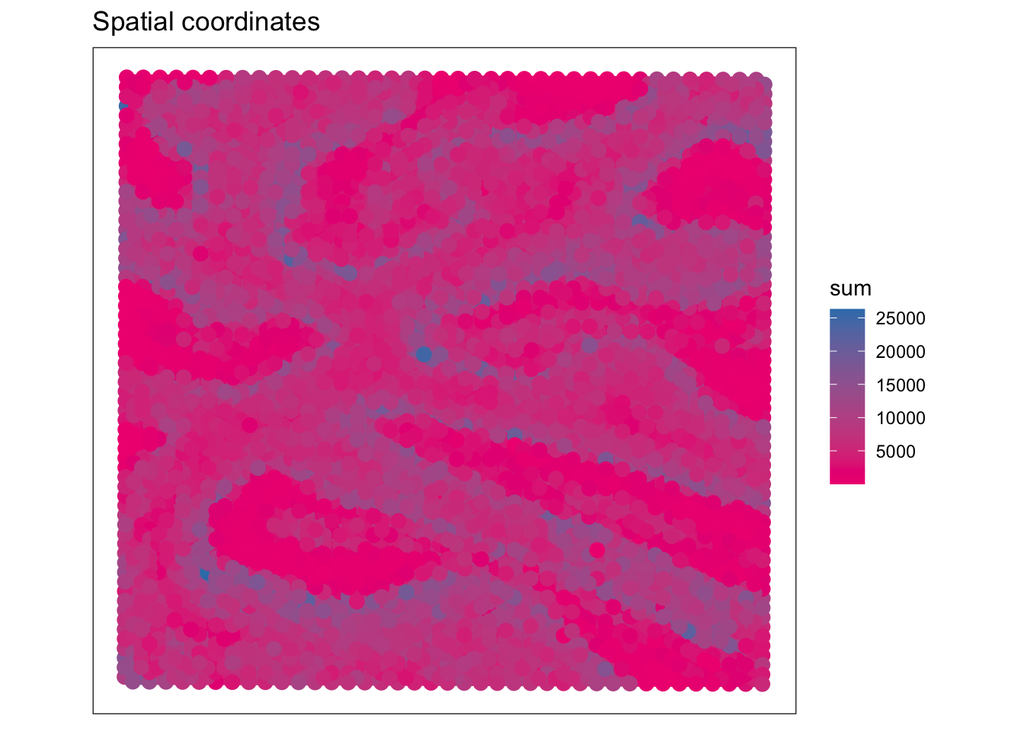

```r
colData(se)$in_tissue <- TRUE
se <- addPerCellQC(se) # should add MT subset here
plotSpots(se, annotate = "sum", size =3)
```

First, do some filtering, similar to what has been done in the single-cell RNA-seq exercises. For example, you should create a `subset` for mitochondrial genes and remove spots that have extreme values of either mitochondrial content, the number of reads or genes observed. To save some computational time for the spatial measures, you may also want to filter out genes that are lowly expressed or in few cells.

Second, compute for each gene a measure of *variability* (e.g., biological variability from `scran::modelGeneVar`) and a measure of *spatial variability* (e.g., Moran’s I). Make a plot of the variability versus spatial variaibility (one point for each gene). Does this plot match your expectation (e.g., genes that are spatially variable should also be variable) ? Using `plotSpots()` or similar, plot a few interesting genes in terms of their spatial variability.

## Question 2. Cluster using `BayesSpace` (or similar)

Using the dataset from Question 1, cluster the spots into spatial domains (or clusters). You could use BayesSpace ([see vignette here](https://www.bioconductor.org/packages/release/bioc/vignettes/BayesSpace/inst/doc/BayesSpace.html)), but there are many other options. Make a nice plot of the spots coloured by cluster.

## Question 3. Find marker genes of the clusters

Using the clusters from Question 2, find marker genes for the clusters (e.g., using `findMarkers`, analogous to what one typically does with clusters from scRNA-seq data). Find a way to summarize the `findMarkers` (or similar analysis) results into a single number (e.g., overall P-value, or F-statistic representing the departure from the null of equal expression in all clusters) for each gene. Plot this value against the measure of spatial variability above (Question 1). Make a plot of a few genes (in spatial coordinates using `plotSpots()` or similar) to help you understand any similarity (or lack of similarity) between the differential-expression-statistics-linked-to-spatial-clusters (Question 3) and the spatial-variability statistics (Question 1).

## Question 4. Explore spatial point patterns and explore K functions.

Consider the following 4 spatial point patterns:

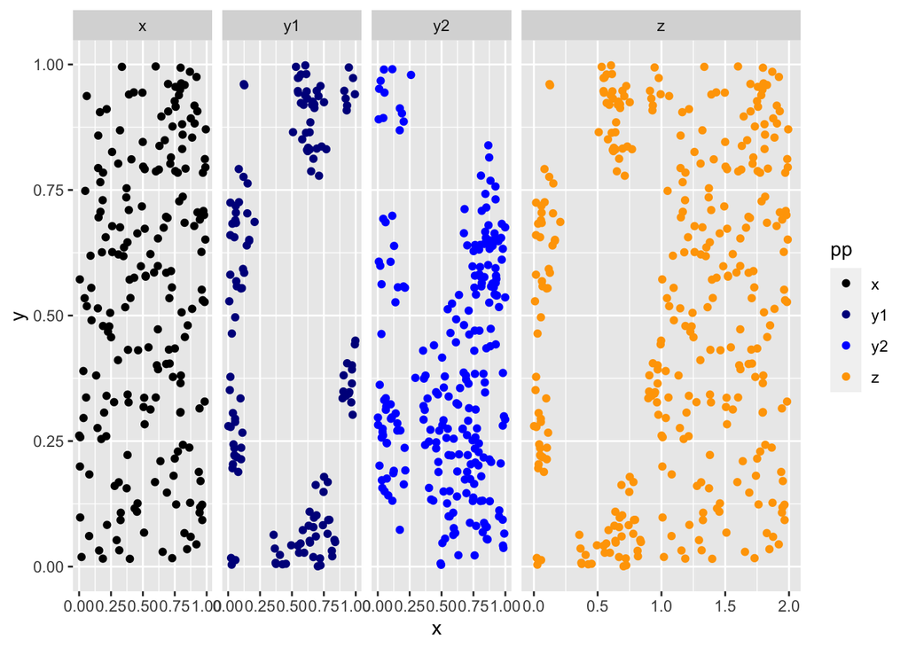

```r
set.seed(12345)

# completely random process
x <- rpoint(200)

nclust <- function(x0, y0, radius, n)
  runifdisc(n, radius, centre=c(x0, y0))

# clustered process
y1 <- rPoissonCluster(12.5, 0.5, nclust, radius=0.1, n=16)
y2 <- rPoissonCluster(12.5, 0.5, nclust, radius=0.15, n=16)


x_df <- as.data.frame(x)
y1_df <- as.data.frame(y1)

# hacky construction of a mixed point process
x_df_star <- cbind(x=x$x+1, y=x$y)
z_df <- rbind(x_df_star, y1_df)
z <- as.ppp(z_df, c(0,2,0,1))

# make a list of point patterns and plot them
pps <- list(x=x, y1=y1, y2=y2, z=z)

dfs <- mapply(function(u,v) {
  cbind(as.data.frame(u), pp=v)
}, pps, names(pps), SIMPLIFY = FALSE) %>% bind_rows()

cols <- c("x" = "black",
          "y1" = "blue4",
          "y2" = "blue",
          "z" = "orange")

ggplot(dfs, aes(x,y, colour=pp)) +
  geom_point() +
  facet_grid(~pp, scales = "free_x", space = "free_x") +
  scale_colour_manual(values = cols)
```

Calculate Ripley’s K function (e.g., `Kinhom`, among many choices in the `spatstat` package) for each of the 4 point processes above and overlay them in a single plot (with different colour or line type for each). Comment on the plot (e.g., is the most-clustered point process where you would expect it, relative to the completely spatially random process?).